# TS Zillow Team Project (VAR CV model)

#### Tests

```r
kpss.test(Median_price_ts_train_diff2)
```

```
##
##  KPSS Test for Level Stationarity
##
## data:  Median_price_ts_train_diff2
## KPSS Level = 0.015469, Truncation lag parameter = 4, p-value = 0.1
```

```r
kpss.test(Average_rate_ts_train_diff1_cut)
```

```
##
##  KPSS Test for Level Stationarity
##
## data:  Average_rate_ts_train_diff1_cut
## KPSS Level = 0.25475, Truncation lag parameter = 4, p-value = 0.1
```

```r
adf.test(Median_price_ts_train_diff2)
```

```
##
##  Augmented Dickey-Fuller Test
##
## data:  Median_price_ts_train_diff2
## Dickey-Fuller = -6.8136, Lag order = 5, p-value = 0.01
## alternative hypothesis: stationary
```

```r
adf.test(Average_rate_ts_train_diff1_cut)
```

```
##
##  Augmented Dickey-Fuller Test
##
## data:  Average_rate_ts_train_diff1_cut
## Dickey-Fuller = -5.9351, Lag order = 5, p-value = 0.01
## alternative hypothesis: stationary
```

#### VAR select

```r
# Use VAR select
model1_diff21 <- VARselect(cbind(Median_price_ts_train_diff2, Average_rate_ts_train_diff1_cut))

# Print the model
model1_diff21
```

```
## $selection
## AIC(n)  HQ(n)  SC(n) FPE(n)
##     10      1      1     10
##
## $criteria
##                    1             2             3             4             5
## AIC(n)      14.54841      14.58401      14.62251      14.65525      14.63384
## HQ(n)       14.60531      14.67884      14.75528      14.82595      14.84248
## SC(n)       14.68854      14.81755      14.94947      15.07562      15.14763
## FPE(n) 2081153.63992 2156732.99005 2241782.14712 2317110.31737 2269115.50954
##                    6             7             8             9            10
## AIC(n)      14.65006      14.57591      14.47988      14.40779      14.23312
## HQ(n)       14.89663      14.86041      14.80232      14.76815      14.63142
## SC(n)       15.25727      15.27653      15.27392      15.29524      15.21398
## FPE(n) 2307817.49334 2144914.01676 1950934.30032 1818090.83133 1529701.86092
```

`VARselect` offers us to try model with p = 10.

#### Model

```r
# Var 10
varmodel10_diff21 <- VAR(cbind(Median_price_ts_train_diff2, Average_rate_ts_train_diff1_cut), p = 10, type = "both", season = 12)

# Pormonteau test
serial.test(varmodel10_diff21, lags.pt = 20, type = "PT.asymptotic")
```

```
##
##  Portmanteau Test (asymptotic)
##
## data:  Residuals of VAR object varmodel10_diff21
## Chi-squared = 52.354, df = 40, p-value = 0.09125
```

```r
# Print model
summary(varmodel10_diff21)
```

```
##
## VAR Estimation Results:
## =========================
## Endogenous variables: Median_price_ts_train_diff2, Average_rate_ts_train_diff1_cut
## Deterministic variables: both
## Sample size: 119
## Log Likelihood: -1070.469
## Roots of the characteristic polynomial:
## 0.9565 0.9565 0.9258 0.9258 0.9084 0.9084 0.9017 0.9017 0.8942 0.8942 0.8731 0.8731 0.871 0.871 0.8677 0.8677 0.8653 0.8653 0.8308  0.66
## Call:
## VAR(y = cbind(Median_price_ts_train_diff2, Average_rate_ts_train_diff1_cut),
##     p = 10, type = "both", season = 12L)
##
##
## Estimation results for equation Median_price_ts_train_diff2:
## ============================================================
## Median_price_ts_train_diff2 = Median_price_ts_train_diff2.l1 + Average_rate_ts_train_diff1_cut.l1 + Median_price_ts_train_diff2.l2 + Average_rate_ts_train_diff1_cut.l2 + Median_price_ts_train_diff2.l3 + Average_rate_ts_train_diff1_cut.l3 + Median_price_ts_train_diff2.l4 + Average_rate_ts_train_di…
##
##                                         Estimate   Std. Error t value
## Median_price_ts_train_diff2.l1          -1.04298      0.09828 -10.613
## Average_rate_ts_train_diff1_cut.l1    -489.35448   3601.07731  -0.136
## Median_price_ts_train_diff2.l2          -0.78285      0.13338  -5.869
## Average_rate_ts_train_diff1_cut.l2   -1621.56846   3355.77982  -0.483
## Median_price_ts_train_diff2.l3          -0.67999      0.13960  -4.871
## Average_rate_ts_train_diff1_cut.l3   -6809.29250   3386.04275  -2.011
## Median_price_ts_train_diff2.l4          -0.74515      0.14328  -5.200
## Average_rate_ts_train_diff1_cut.l4    4335.18796   3367.76974   1.287
## Median_price_ts_train_diff2.l5          -0.82785      0.14666  -5.645
## Average_rate_ts_train_diff1_cut.l5    -683.38995   3202.40222  -0.213
## Median_price_ts_train_diff2.l6          -0.63866      0.14394  -4.437
## Average_rate_ts_train_diff1_cut.l6    1328.15338   3176.44613   0.418
## Median_price_ts_train_diff2.l7          -0.65370      0.13786  -4.742
## Average_rate_ts_train_diff1_cut.l7    1746.83264   3175.37937   0.550
## Median_price_ts_train_diff2.l8          -0.68640      0.13872  -4.948
## Average_rate_ts_train_diff1_cut.l8   -7310.70102   3123.75145  -2.340
## Median_price_ts_train_diff2.l9          -0.60300      0.13404  -4.499
## Average_rate_ts_train_diff1_cut.l9   -3352.76278   3156.11248  -1.062
## Median_price_ts_train_diff2.l10         -0.41995      0.09712  -4.324
## Average_rate_ts_train_diff1_cut.l10  -2004.93266   3111.56221  -0.644
## const                                 -208.16476   1210.03526  -0.172
```

[output cut: 137 more lines]

```
## Covariance matrix of residuals:
##                                 Median_price_ts_train_diff2
## Median_price_ts_train_diff2                     21552577.76
## Average_rate_ts_train_diff1_cut                       87.35
##                                 Average_rate_ts_train_diff1_cut
## Median_price_ts_train_diff2                            87.35048
## Average_rate_ts_train_diff1_cut                         0.02017
##
## Correlation matrix of residuals:
##                                 Median_price_ts_train_diff2
## Median_price_ts_train_diff2                          1.0000
## Average_rate_ts_train_diff1_cut                      0.1325
##                                 Average_rate_ts_train_diff1_cut
## Median_price_ts_train_diff2                              0.1325
## Average_rate_ts_train_diff1_cut                          1.0000
```

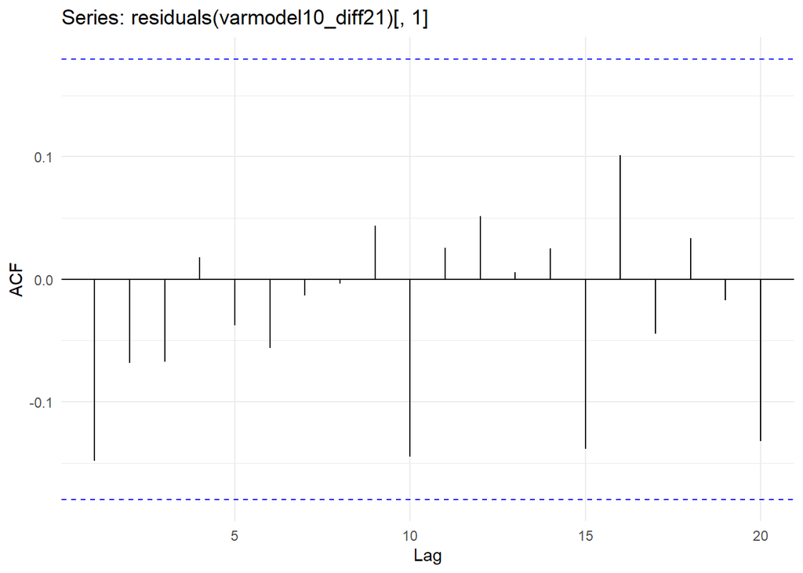

```r
# Check residuals for the model
ggAcf(residuals(varmodel10_diff21)[, 1])
```

#### Forecast

```r
# Create a forecast
varmodel10_diff21_forecast <- ts(predict(varmodel10_diff21, n.ahead = 12, ci = .95)$fcst$Median_price_ts_train[, 1], start = test_start, frequency = 12)
```

#### Evaluate the model

```r
# Analyze accuracy
accuracy(varmodel10_diff21_forecast, Median_price_ts_test_diff2)
```

```
##                 ME     RMSE      MAE MPE MAPE       ACF1 Theil's U
## Test set -137.3009 7703.266 6477.213 Inf  Inf -0.6912366         0
```

```r
accuracy(varmodel10_diff21_forecast, Average_rate_ts_test_diff1_cut)
```

```
##                 ME     RMSE      MAE      MPE     MAPE       ACF1 Theil's U
## Test set -283.2109 8340.751 6198.048 -8878407 12879933 -0.3623703  79040.85
```

#### Cross-validation

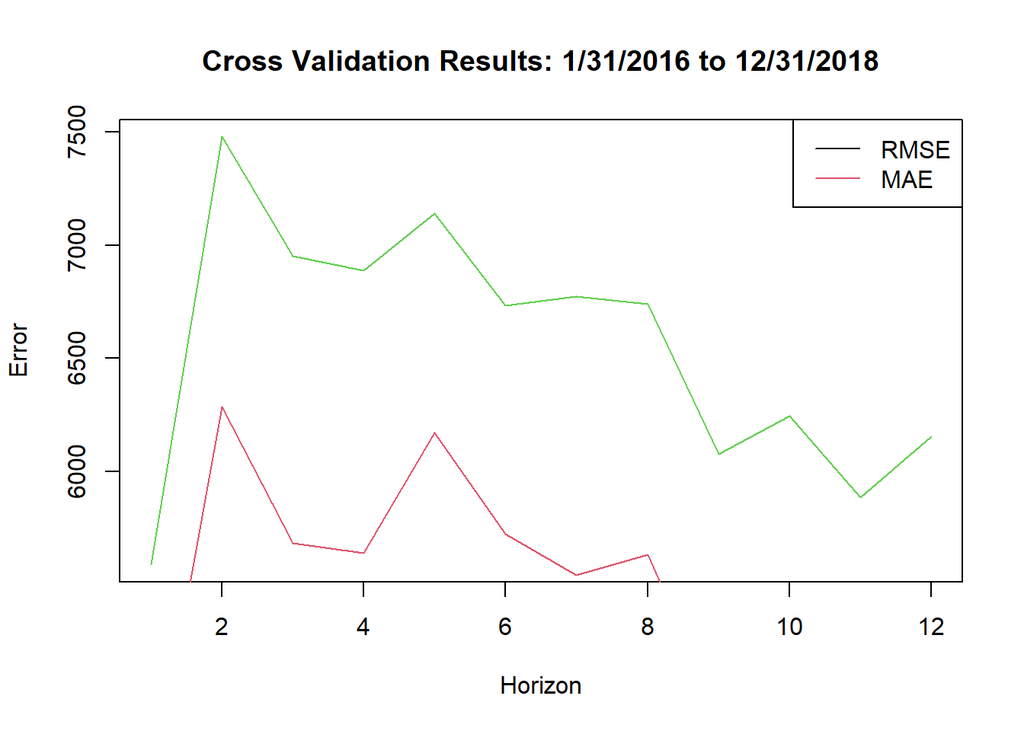

```r
# Define parameters
k <- 72 # Minimum observations (6 years)
p <- 12 # Period
st <- 2014 + 11/12
error <- matrix(NA, 36, 12)
dates <- c()
for(i in (1:36))

# Create a function
{
  train <- window(Median_price_ts_diff2, start = st + (i - k + 1)/p, end = st + i/p)
  test <- window(Median_price_ts_diff2, start = st + (i + 1)/p, end = st + (i + 12)/p)
  rate_train <- window(Average_rate_ts_diff1_cut, start = st + (i - k + 1)/p, end = st + i/p)
  rate_test <- window(Average_rate_ts_diff1_cut, start = st + (i + 1)/p, end = st+(i + 12)/p)
  dates[i] <- st + (i + 12)/p
  var_model <-  VAR(cbind(train, rate_train), p = 10, type = "both", season = 12)

  f <- ts(predict(var_model, n.ahead = 12, ci = .95)$fcst$train[, 1], start = st + (i + 1)/p, frequency = 12)
  error[i, 1:length(test)] <- f - test
}

# Define and plot metrics
MAE <- colMeans(abs(error), na.rm = TRUE)
RMSE <- sqrt(colMeans(error**2, na.rm = TRUE))
plot(1:12, RMSE, type = "l", col = 3, xlab = "Horizon", ylab = "Error", main = 'Cross Validation Results: 1/31/2016 to 12/31/2018')
lines(1:12, MAE, type = "l", col = 2)
legend("topright", legend = c("RMSE", "MAE"), col = 1:4, lty = 1)
```

```r
# Print metrics
print(MAE)
```

```
##  [1] 4554.571 6284.197 5683.381 5638.706 6169.465 5720.829 5540.166 5630.728
##  [9] 4918.105 5042.146 4792.340 5153.924
```

```r
print(RMSE)
```

```
##  [1] 5586.948 7479.513 6951.721 6889.197 7141.218 6732.974 6772.688 6738.507
##  [9] 6076.763 6244.364 5882.923 6154.446
```

```r
print(sum(MAE)/12)
```

```
## [1] 5427.38
```

```r
print(sum(RMSE)/12)
```

```
## [1] 6554.272
```

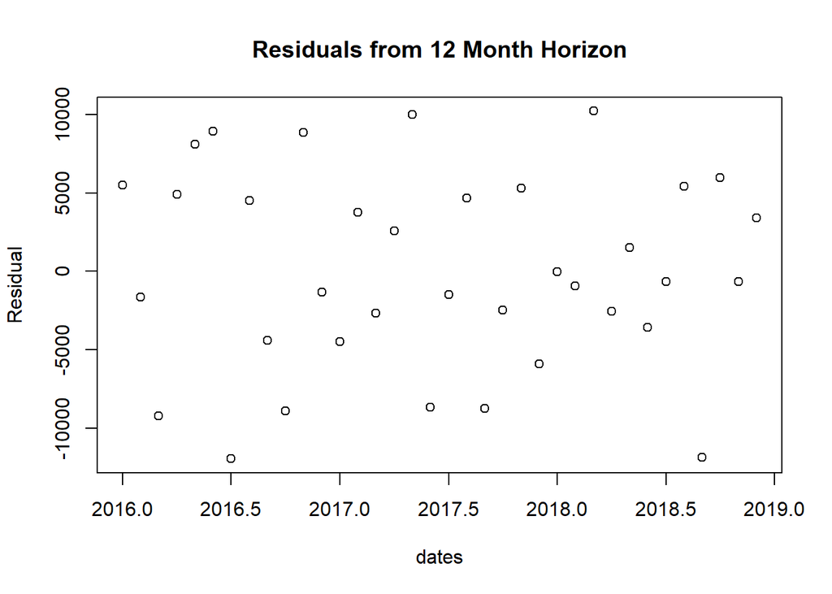

```r
# Plot residuals
plot(dates, error[, 12], ylab = 'Residual', main = 'Residuals from 12 Month Horizon')
```

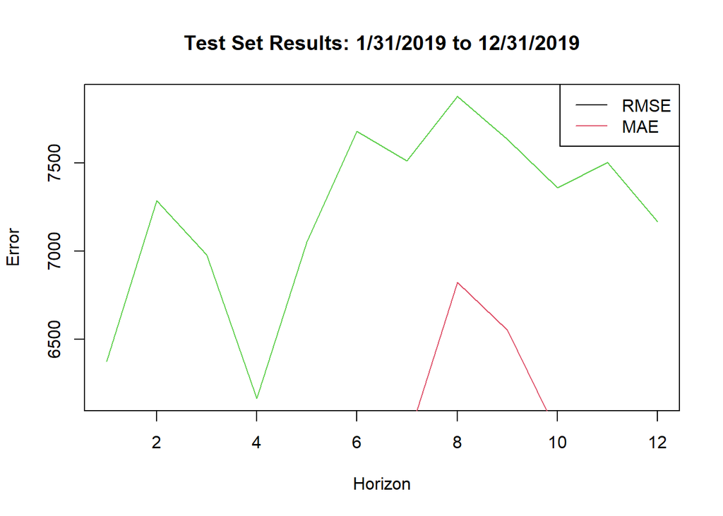

```r
error <- matrix(NA, 12, 12)
dates <- c()
for(i in (37:48))

{
  train <- window(Median_price_ts_diff2, start = st + (i - k + 1)/p, end = st + i/p)
  test <- window(Median_price_ts_diff2, start = st + (i + 1)/p, end = st + (i + 12)/p)
  rate_train <- window(Average_rate_ts_diff1_cut, start = st + (i - k + 1)/p, end = st + i/p)
  rate_test <- window(Average_rate_ts_diff1_cut, start = st + (i + 1)/p, end = st + (i + 12)/p)
  dates[i - 36] <- st + (i + 12)/p
  var_model <-  VAR(cbind(train, rate_train), p = 8, type = "both", season = 12)

  f <- ts(predict(var_model, n.ahead = 12, ci = .95)$fcst$train[, 1], start = st + (i + 1)/p, frequency = 12)
  error[i - 36, 1:length(test)] <- f - test
}

# Define metrics and plot them
MAE <- colMeans(abs(error), na.rm = TRUE)
RMSE <- sqrt(colMeans(error**2, na.rm = TRUE))
plot(1:12, RMSE, type = "l",col = 3, xlab = "Horizon", ylab = "Error", main = 'Test Set Results: 1/31/2019 to 12/31/2019')
lines(1:12, MAE, type = "l", col = 2)
legend("topright", legend = c("RMSE", "MAE"), col = 1:4, lty = 1)
```

```r
# Print metrics
print(MAE)
```

```
##  [1] 5853.881 5869.890 5365.119 5259.328 5341.403 6044.195 5916.029 6821.520
##  [9] 6551.531 5969.702 6066.474 5848.472
```

```r
print(RMSE)
```

```
##  [1] 6374.754 7285.744 6977.199 6164.417 7049.963 7677.960 7511.185 7875.040
##  [9] 7633.202 7357.425 7502.761 7167.921
```

```r
print(sum(MAE)/12)
```

```
## [1] 5908.962
```

```r
print(sum(RMSE)/12)
```

```
## [1] 7214.798
```

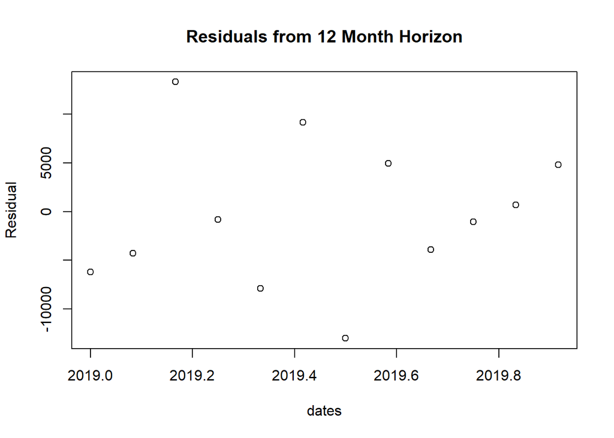

```r
# Plot residuals
plot(dates, error[, 12], ylab = 'Residual', main = 'Residuals from 12 Month Horizon')
```

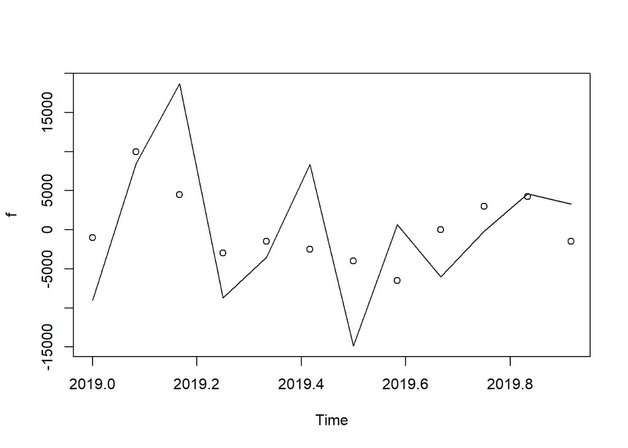

```r
# Compare
plot(f)
points(test)
```

### Conclusion

```r
# Print accuracy again
accuracy(varmodel8_forecast, Median_price_ts_test_diff1)
```

```
##                 ME    RMSE      MAE       MPE     MAPE       ACF1 Theil's U
## Test set -1106.187 4412.83 3502.727 -3.134251 139.6127 -0.3275504  1.139328
```

```r
accuracy(varmodel8_forecast, Average_rate_ts_test_diff1)
```

```
##                 ME     RMSE      MAE      MPE     MAPE      ACF1 Theil's U
## Test set -1939.597 8061.648 6329.194 -1788137 10487641 0.4442023  59444.59
```

THis results are similar to the best results, obtained by other team members in their VAR and ARIMA models.

### Useful resources

- [StackOverflow - VAR methodology](https://stats.stackexchange.com/questions/191851/var-forecasting-methodology/195477#195477)
- [Forecasting methodology and k-fold cross validation for a vector autoregression](https://stats.stackexchange.com/questions/200598/forecasting-methodology-and-k-fold-cross-validation-for-a-vector-autoregression)
- [Introduction to Econometrics with R - Vector Autoregressions](https://www.econometrics-with-r.org/16-1-vector-autoregressions.html)
- [Forecasting: Principles and Practice](https://otexts.com/fpp3/VAR.html)
- [Penn State - Vector Autoregressive models VAR(p) models](https://online.stat.psu.edu/stat510/lesson/11/11.2)
- [VAR model tutorial](https://rpubs.com/bostonchopsticks/405570)
- [Presentation](http://www.ams.sunysb.edu/~zhu/ams586/VAR_Lecture2.pdf)